# FlipTheFleet Test Black Box Data: Codebook

EVBlackBox export 2018-09-08-081400.csv.gz

Ben Anderson (b.anderson@soton.ac.uk, `@dataknut`)

Last run at: 2018-11-12 12:58:16

# 1 About

## 1.1 License

This work is (c) the author(s).

This work is licensed under a [Creative Commons Attribution 4.0 International License](http://creativecommons.org/licenses/by/4.0/) unless otherwise marked.

For the avoidance of doubt and explanation of terms please refer to the full [license notice](https://creativecommons.org/licenses/by/4.0/) and [legal code](https://creativecommons.org/licenses/by/4.0/legalcode).

## 1.2 Citation

If you wish to use any of the material from this report please cite as:

- Anderson, B. (2018) FlipTheFleet Test Black Box Data: Codebook: (File: EVBlackBox export 2018-09-08-081400.csv.gz), [Centre for Sustainability](http://www.otago.ac.nz/centre-sustainability/), University of Otago: Dunedin, New Zealand.

This work is (c) 2018 the University of Southampton.

## 1.3 Purpose

This report is intended to:

- load and test preliminary ‘black box’ EV monitoring data provided for assessment purposes by [FlipTheFleet](http://flipthefleet.org/).

## 1.4 Requirements

- test dataset: EVBlackBox export 2018-09-08-081400.csv.gz

## 1.5 History

Specific history of this report:

- https://github.com/CfSOtago/evAnalysis/commits/master/ftf/dataProcessing/ftFBlackBoxTestDataCodebook.Rmd

## 1.6 Acknowledgements

Data provided by [FlipTheFleet](https://flipthefleet.org/ev-black-box/).

This work was supported by:

- The New Zealand [Ministry of Business, Innovation and Employment (MBIE)](http://www.mbie.govt.nz/) through the [Renewable Energy and the Smart Grid (GREEN Grid)](https://www.otago.ac.nz/centre-sustainability/research/energy/otago050285.html) project;
- [SPATIALEC](http://www.energy.soton.ac.uk/tag/spatialec/) - a [Marie Skłodowska-Curie Global Fellowship](http://ec.europa.eu/research/mariecurieactions/about-msca/actions/if/index_en.htm) based at the University of Otago’s [Centre for Sustainability](http://www.otago.ac.nz/centre-sustainability/staff/otago673896.html) (2017-2019) & the University of Southampton’s Sustainable Energy Research Group (2019-2020).

# 2 Load data files

In this section we load, merge and describe /Volumes/hum-csafe/Research Projects/GREEN Grid/externalData/flipTheFleet/raw/testData/EVBlackBox export 2018-09-08-081400.csv.gz.

Original data:

```
## Skim summary statistics
##  n obs: 34254
##  n variables: 221
##
## ── Variable type:character ───────────────────────────────────────────────────────────────────────────────────────────────────────
##         variable missing complete     n min  max empty n_unique
##      ambient_54c    8232    26022 34254   3   31     0       34
##      ambient_56f    8232    26022 34254   3    3     0        1
##   ambient_temp_1   34254        0 34254 Inf -Inf     0        0
##     cabin_temp_2   34254        0 34254 Inf -Inf     0        0
##  dash_odo_units2   29003     5251 34254   2    2     0        1
##      dash_units1   29003     5251 34254   2    2     0        1
##       Date (GPS)   16312    17942 34254  10   10     0       58
##             gear   16309    17945 34254   1    1     0        5
##    is_climate_on       0    34254 34254   4    5     0        2
##  Pack 3 temp (C)   34254        0 34254 Inf -Inf     0        0
##           Reg No       0    34254 34254   6    6     0        1
##              VIN   27365     6889 34254  11   11     0        1
##
## ── Variable type:difftime ────────────────────────────────────────────────────────────────────────────────────────────────────────
##    variable missing complete     n    min        max     median n_unique
##  Time (GPS)   16312    17942 34254 6 secs 86391 secs 38886 secs    13780
##
## ── Variable type:integer ─────────────────────────────────────────────────────────────────────────────────────────────────────────
##                 variable missing complete     n    mean       sd    p0
##              avg_cp (mV)   13329    20925 34254 3988.33    98.69  3514
##                     cp_1   13329    20925 34254 -217.03  3982.21 -4127
##                    cp_10   13329    20925 34254  271.31  3982.01 -4132
##                    cp_11   13329    20925 34254  516.23  3954.82 -4132
##                    cp_12   13329    20925 34254  332.18  3975.19 -4132
##                    cp_13   13329    20925 34254  750.75  3918.87 -4127
##                    cp_14   13329    20925 34254  651.7   3935.45 -4132
##                    cp_15   13329    20925 34254  254.47  3980.02 -4132
##                    cp_16   13329    20925 34254  968.54  3868.48 -4133
##                    cp_17   13329    20925 34254 1500.45  3697.11 -4133
##                    cp_18   13329    20925 34254 1500.91  3697.68 -4133
##                    cp_19   13329    20925 34254  254.2   3980.66 -4132
##                     cp_2   13329    20925 34254  819.6   3904.89 -4132
##                    cp_20   13329    20925 34254  840.34  3899.5  -4134
##                    cp_21   13329    20925 34254 1488.81  3701.07 -4133
```

[output cut: 315 more lines]

```
##   263.53       0       0       0       0     4092    ▇▁▁▁▁▁▁▁
##    18.28       0       0       0      26      157    ▇▂▁▁▁▁▁▁
##     0.43      14      15      15      15       15    ▂▁▁▁▁▁▁▇
##     0.82      58      59      59      60       62    ▁▇▁▆▁▁▁▁
##     4.04     151     152     156     160      163    ▇▁▂▁▁▇▁▃
##     7.34     328     333     340     343      360    ▅▇▇▂▂▃▁▁
##    13.03     692     708     723     728      755    ▂▃▂▅▇▂▁▁
##    27.71     940     952     981    1011     1032    ▇▂▅▅▃▃▇▂
##  [ reached getOption("max.print") -- omitted 14 rows ]
##
## ── Variable type:POSIXct ─────────────────────────────────────────────────────────────────────────────────────────────────────────
##        variable missing complete     n        min        max     median
##  cell_longitude   32002     2252 34254 2018-07-11 2018-09-07 2018-08-02
##  n_unique
##      2252
```

# 3 Location inference

The raw data has latitude and longitude. This is very disclosive, although there are likely to be errors. For example 0 values in the table below (off the coast of West Africa) may indicate GPS signal issues.

Table 3.1: Summary of test geo data

|  | Longitude | Latitude | Altitude | ambient_temp_1 |
| --- | --- | --- | --- | --- |
|  | Min. : 0.0 | Min. :-44.26 | Min. :-953.9 | Length:34254 |
|  | 1st Qu.:172.6 | 1st Qu.:-43.39 | 1st Qu.: 13.6 | Class :character |
|  | Median :172.6 | Median :-43.37 | Median : 22.8 | Mode :character |
|  | Mean :168.2 | Mean :-42.25 | Mean : 39.9 | NA |
|  | 3rd Qu.:172.6 | 3rd Qu.:-43.37 | 3rd Qu.: 33.6 | NA |
|  | Max. :173.5 | Max. : 0.00 | Max. : 949.3 | NA |
|  | NA’s :15840 | NA’s :15840 | NA’s :15840 | NA |

[interactive chart not shown]

Figure 3.1: Map of sample of observations

Figure 3.1 maps the location of a random sample of 50 of the observations in the dataset. If we selected just one vehicle and zoomed our map to the location at 01:00 - 04:00 when speed is 0 then we would probably determine their home. We could also determine other places visited at other times… This indicates how [disclosive GPS Lat/Long can be](http://toddwschneider.com/posts/analyzing-1-1-billion-nyc-taxi-and-uber-trips-with-a-vengeance/) even if address data is not provided.

# 4 Derived variables

Create some useful derived variables.

```r
# create derived
ftfDT <- evAnalysis::ftfCreateDerived(ftfDT)
```

If there is a ‘failed to parse’ message it suggests some dates and times could not be correctly parsed by `evAnalysis::ftfCreateDerived()`. We can check this using by comparing the original and parsed variables:

```
## Date (GPS)
```

```
##    Length     Class      Mode
##     34254 character character
```

```
## Time (GPS)
```

```
##   Length   Class1   Class2     Mode
##    34254      hms difftime  numeric
```

```
## rDateTime
```

```
##                  Min.               1st Qu.                Median
## "2018-07-12 11:02:49" "2018-07-21 13:55:27" "2018-08-07 05:50:48"
##                  Mean               3rd Qu.                  Max.
## "2018-08-07 21:09:01" "2018-08-21 14:44:35" "2018-09-08 15:27:48"
##                  NA's
##               "16312"
```

It looks like the dates don’t always parse. Check a few…

Table 4.1: Example rows where date failed to parse

| Date (GPS) | rDateTime | Time (GPS) |
| --- | --- | --- |
| NA | NA | NA |
| NA | NA | NA |
| NA | NA | NA |
| NA | NA | NA |
| NA | NA | NA |
| NA | NA | NA |

Doesn’t look like we can do much about these…

# 5 Preventing geo-disclosure

To avoid any risk of location disclosure we next infer a very coarse geo-location at each time point so that we can remove the potentially disclosive GPS data before moving on to the analysis.

Note that this does not necessarily render this dataset *completely safe* ([anonymised](https://www.ukdataservice.ac.uk/manage-data/legal-ethical/anonymisation)) as there may well be other variables that provide sufficient information either on their own or together which would [enable identification](https://www.ukdataservice.ac.uk/manage-data/legal-ethical/anonymisation) of the car and it’s owner.

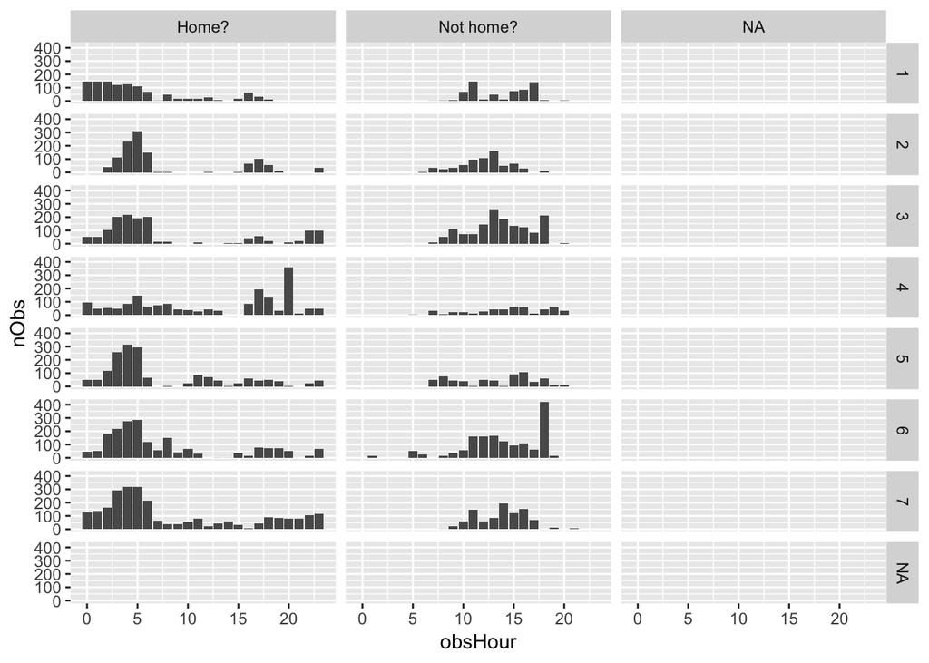

Figure 5.1: Check inferred location

```r
plotDT <- ftfDT[, .(nObs = .N),
                keyby = .(derivedLocation, obsHour = lubridate::hour(rDateTime), rDow = lubridate::wday(rDateTime))]

ggplot(plotDT, aes(x = obsHour, y = nObs)) +
  geom_col() +
  facet_grid(rDow ~ derivedLocation)
```

Figure 5.1 shows the results of this inference. Does it look like a reasonable guestimate of location?

# 6 Make safe version

We now create a unique EV ID by hashing the `Reg No` and then removing the following variables before we do anything else as they are potentially disclosive:

- `Reg No`
- `Latitude`
- `Longitude`
- `Course (deg)`

That gives us a data file with:

- 34,254 rows of data
- 224 columns (variables)
- 1 EVs

# 7 Codebook

Describe data to create codebook:

```
## ftfSafeDT
##
##  224  Variables      34254  Observations
## ---------------------------------------------------------------------------
## Time after power on (s)
##        n  missing distinct     Info     Mean      Gmd      .05      .10
##    34254        0    12724        1     4860     5785      176      284
##      .25      .50      .75      .90      .95
##      715     2266     6990    12748    18621
##
## lowest :    23    24    25    26    27, highest: 32581 32611 32678 32744 32811
## ---------------------------------------------------------------------------
## Date (GPS)
##        n  missing distinct
##    17942    16312       58
##
## lowest : 01-08-2018 01-09-2018 02-08-2018 03-08-2018 03-09-2018
## highest: 29-08-2018 30-07-2018 30-08-2018 31-07-2018 31-08-2018
## ---------------------------------------------------------------------------
## Time (GPS) [secs]
##        n  missing distinct
##    17942    16312    13780
##
## lowest : 00:00:06 00:00:13 00:00:25 00:00:34 00:00:35
## highest: 23:59:25 23:59:30 23:59:34 23:59:41 23:59:51
## ---------------------------------------------------------------------------
## Altitude
##        n  missing distinct     Info     Mean      Gmd      .05      .10
##    18414    15840     1433        1     39.9    51.59      0.0      0.8
##      .25      .50      .75      .90      .95
##     13.6     22.8     33.6     47.0    185.1
##
## lowest : -953.9 -461.0 -387.8 -293.2 -291.1, highest:  766.2  771.4  778.8  787.2  949.3
## ---------------------------------------------------------------------------
## Speed (GPS)
##        n  missing distinct     Info     Mean      Gmd      .05      .10
##    18414    15840       61     0.61    18.08    28.69     0.00     0.00
##      .25      .50      .75      .90      .95
##     0.00     0.00    22.22    85.19    90.75
##
```

[output cut: 2416 more lines]

```
## ---------------------------------------------------------------------------
## evID
##                                n                          missing
##                            34254                                0
##                         distinct                            value
##                                1 44e70b238906b67964c088be78366d2c
##
## Value      44e70b238906b67964c088be78366d2c
## Frequency                             34254
## Proportion                                1
## ---------------------------------------------------------------------------
##
## Variables with all observations missing:
##
## [1] Pack 3 temp (C) ambient_temp_1  cabin_temp_2
```

# 8 Save safe data out

Save the safe data for future use and gzip it.

```
## Gziping /Volumes/hum-csafe/Research Projects/GREEN Grid/externalData/flipTheFleet/safe/EVBlackBox export 2018-09-08-081400.csv.gz_safe.csv
```

```
## Gzipped /Volumes/hum-csafe/Research Projects/GREEN Grid/externalData/flipTheFleet/safe/EVBlackBox export 2018-09-08-081400.csv.gz_safe.csv
```

Gzipped the file to reduce it from 27.86 MB to 3.02 MB.

# 9 Runtime

Analysis completed in 17 seconds ( 0.28 minutes) using knitr in [RStudio](http://www.rstudio.com) with R version 3.5.1 (2018-07-02) running on x86_64-apple-darwin15.6.0.

# 10 R environment

R packages used:

- base R - for the basics (R Core Team 2016)
- data.table - for fast (big) data handling (Dowle et al. 2015)
- lubridate - date manipulation (Grolemund and Wickham 2011)
- ggplot2 - for slick graphics (Wickham 2009)
- readr - for csv reading/writing (Wickham, Hester, and Francois 2016)
- Hmisc - for describe (Harrell Jr, Charles Dupont, and others. 2016)
- knitr - to create this document & neat tables (Xie 2016)
- evAnalysis - for local EV data utilities

# References

Dowle, M, A Srinivasan, T Short, S Lianoglou with contributions from R Saporta, and E Antonyan. 2015. *Data.table: Extension of Data.frame*. https://CRAN.R-project.org/package=data.table.

Grolemund, Garrett, and Hadley Wickham. 2011. “Dates and Times Made Easy with lubridate.” *Journal of Statistical Software* 40 (3): 1–25. http://www.jstatsoft.org/v40/i03/.

Harrell Jr, Frank E, with contributions from Charles Dupont, and many others. 2016. *Hmisc: Harrell Miscellaneous*. https://CRAN.R-project.org/package=Hmisc.

R Core Team. 2016. *R: A Language and Environment for Statistical Computing*. Vienna, Austria: R Foundation for Statistical Computing. https://www.R-project.org/.

Wickham, Hadley. 2009. *Ggplot2: Elegant Graphics for Data Analysis*. Springer-Verlag New York. http://ggplot2.org.

Wickham, Hadley, Jim Hester, and Romain Francois. 2016. *Readr: Read Tabular Data*. https://CRAN.R-project.org/package=readr.

Xie, Yihui. 2016. *Knitr: A General-Purpose Package for Dynamic Report Generation in R*. https://CRAN.R-project.org/package=knitr.